# Iris Data Set

Eric Leung

April 21, 2015

# Introduction

The Iris Data Set was downloaded from the UCI Machine Learning Repository.

“This is perhaps the best known database to be found in the pattern recognition literature. Fisher’s paper is a classic in the field and is referenced frequently to this day. (See Duda & Hart, for example.) The data set contains 3 classes of 50 instances each, where each class refers to a type of iris plant. One class is linearly separable from the other 2; the latter are NOT linearly separable from each other.”

1. sepal length in cm
2. sepal width in cm
3. petal length in cm
4. petal width in cm
5. class:
   - Iris Setosa
   - Iris Versicolour
   - Iris Virginica

# Goal

The iris data set contains four potential predictive values: sepal length, sepal width, petal length, and petal width. One or more combinations of these attributes may be used to predict the iris class, which can be one of three classes: Setosa, Versicolour, or virginica.

# Load Packages

```r
library(ggplot2)
library(magrittr)
```

# Load Data

```r
dat <- read.csv(file = "../data/iris-data/iris.data")

# name columns based on attributes above
names(dat) <- c(
    "sepal.length", "sepal.width",
    "petal.length", "petal.width",
    "class")

head(dat)
```

```
##   sepal.length sepal.width petal.length petal.width       class
## 1          4.9         3.0          1.4         0.2 Iris-setosa
## 2          4.7         3.2          1.3         0.2 Iris-setosa
## 3          4.6         3.1          1.5         0.2 Iris-setosa
## 4          5.0         3.6          1.4         0.2 Iris-setosa
## 5          5.4         3.9          1.7         0.4 Iris-setosa
## 6          4.6         3.4          1.4         0.3 Iris-setosa
```

# Explore Data

```r
str(dat)
```

```
## 'data.frame':    149 obs. of  5 variables:
##  $ sepal.length: num  4.9 4.7 4.6 5 5.4 4.6 5 4.4 4.9 5.4 ...
##  $ sepal.width : num  3 3.2 3.1 3.6 3.9 3.4 3.4 2.9 3.1 3.7 ...
##  $ petal.length: num  1.4 1.3 1.5 1.4 1.7 1.4 1.5 1.4 1.5 1.5 ...
##  $ petal.width : num  0.2 0.2 0.2 0.2 0.4 0.3 0.2 0.2 0.1 0.2 ...
##  $ class       : Factor w/ 3 levels "Iris-setosa",..: 1 1 1 1 1 1 1 1 1 1 ...
```

## Explore Sepal Properties

```
## stat_bin: binwidth defaulted to range/30. Use 'binwidth = x' to adjust this.
```

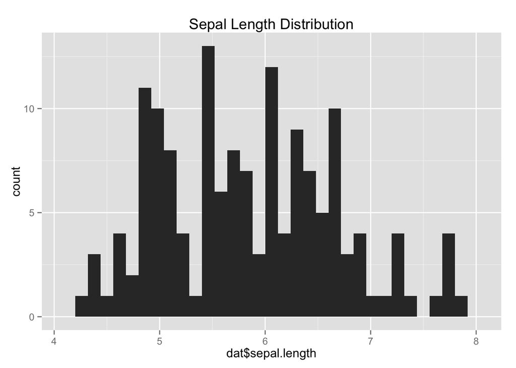

```r
qplot(x = dat$sepal.length, main = "Sepal Length Distribution")
```